# SIRAcon 2014 Survey Results

### Region selection

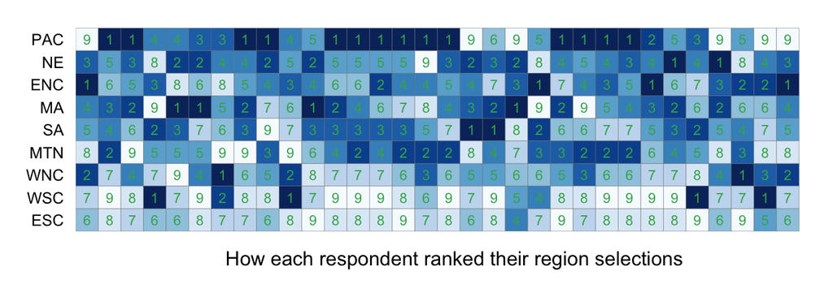

### Top location votes (aggregated):

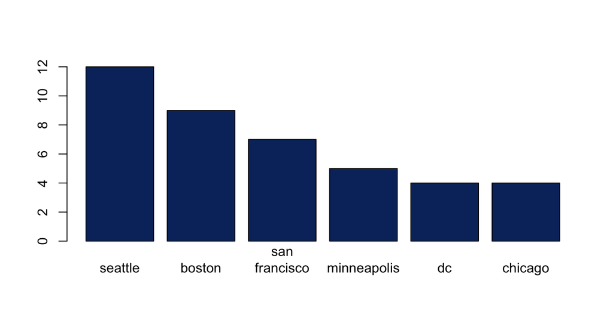

> NOTE: Not everyone filled in a city/state, and some who selected a different region preference chose a cities in different regions … o_O … hence the discrepancy between the two charts.

### Cost & Length

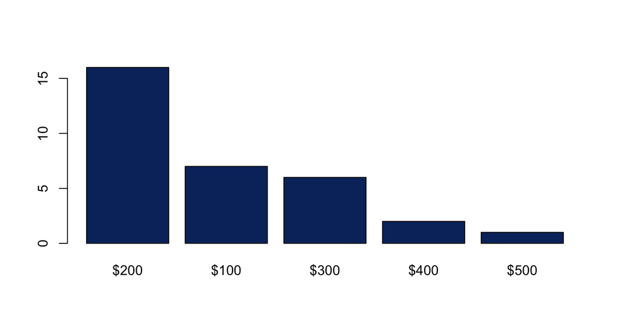

### Topics

Here’s what folks suggested would be good topics:

- “Foundational Risk Principles Risk Management Frameworks Assessing and Measuring Risk Metrics”
- “Maybe a workshop on OpenFAIR or some table top exercises on IT risk assessment. Something a little more hands on than just passive listening.”
- “talks - 1 or 2 tracks iRMBOK training session”
- “I liked the topics in the two tracks (assessment and management) last year, but I wanted to attend them all. I’d rather not run them in parallel.”
- “Hands-on workshops”
- “Reaching out to Metrics folks.”
- “OpenFAIR certification training might be appropriate if it can be condensed into a reasonable period of time.”
- “Practical risk management program implementations. Many organizations don’t have any programs in place today, or if they do they operate in silos and independent of other teams. If a business were to design a risk management program from scratch, how would they go about doing so?”
- “I attended last years conference and thought all of the sessions sounded great, but ended up attending the sessions that leaned towards the”how-to“. Topics around data analysis, visualization would be very interesting. I am at the beginning stages of Risk Analysis so while I find the more”theory" type topics interesting I lean towards the how-to because i find there are the nuggets I can take back with me and apply right away.“
- “Real-life examples of actual quantitative risk management in the real world. The presentation last year from Quicken Loans is the gold standard.”
- “1.Tabletop Exercise 2. Risk Calibration”
- “We need to start covering the market known as Predictive Risk Analytics”
- “Hands on activities using risk models.”

### Finally: Attended Before

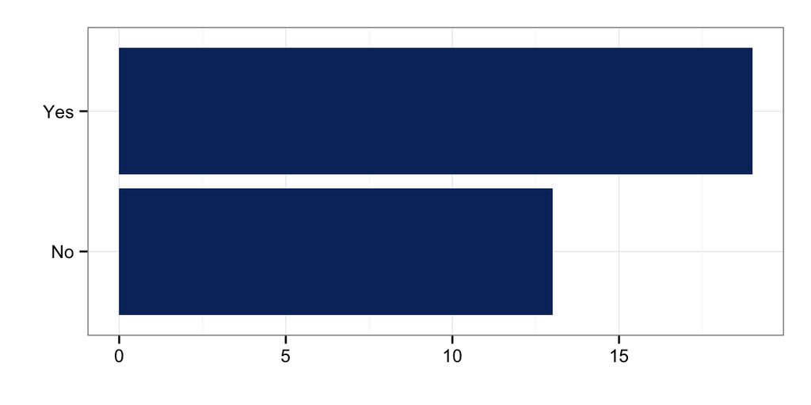